# Lab 2: Linear Regression

Lizzy Presland

January 23, 2019

## Exploring and preparing the data

The data is taken from the .csv file posted on the class Canvas page.

#### Q1: Load the data

To load the data, we would normally use:

```
ins_data <- read.csv("insurance.csv", header=TRUE)
```

Therefore, our load function becomes:

```r
ins_data <- read.csv("insurance.csv", header=TRUE, stringsAsFactors = TRUE)
```

#### Q2: Data structure

```r
head(ins_data)
```

```
##   age    sex    bmi children smoker    region   charges
## 1  19 female 27.900        0    yes southwest 16884.924
## 2  18   male 33.770        1     no southeast  1725.552
## 3  28   male 33.000        3     no southeast  4449.462
## 4  33   male 22.705        0     no northwest 21984.471
## 5  32   male 28.880        0     no northwest  3866.855
## 6  31 female 25.740        0     no southeast  3756.622
```

```r
summary(ins_data)
```

```
##       age            sex           bmi           children     smoker
##  Min.   :18.00   female:662   Min.   :15.96   Min.   :0.000   no :1064
##  1st Qu.:27.00   male  :676   1st Qu.:26.30   1st Qu.:0.000   yes: 274
##  Median :39.00                Median :30.40   Median :1.000
##  Mean   :39.21                Mean   :30.66   Mean   :1.095
##  3rd Qu.:51.00                3rd Qu.:34.69   3rd Qu.:2.000
##  Max.   :64.00                Max.   :53.13   Max.   :5.000
##        region       charges
##  northeast:324   Min.   : 1122
##  northwest:325   1st Qu.: 4740
##  southeast:364   Median : 9382
##  southwest:325   Mean   :13270
##                  3rd Qu.:16640
##                  Max.   :63770
```

#### Q3: Independent and dependent variables

The dependent feature is the **charges** column (the amount of money the insurance company can expect to pay for healthcare costs); the independent features are all others (**age**, **sex**, **bmi**, **number of children**, **tobacco use**, and **geographic region**).

#### Q4: Dependent feature analysis

It is best to analyze the dependent feature numerically; I shall use graphical and numerical methods.

#### Q5: Determine data’s normal distribution

#### Histogram

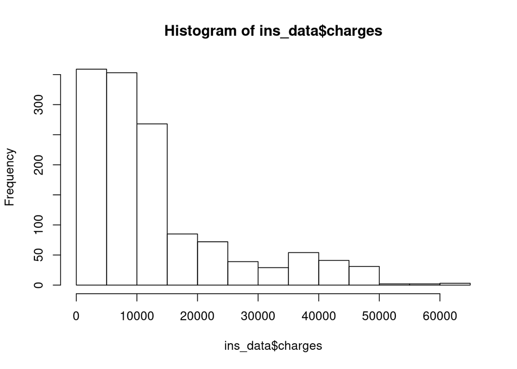

```r
hist(ins_data$charges)
```

As the histogram shows, the data does not appear to be normally distributed; there appears to be a strong right skew to the data.

## Exploring relationships among features using a correlation matrix

#### Q7: create the correlation matrix

```r
numerics <- ins_data[,c(1, 3, 4, 7)]
head(numerics)
```

```
##   age    bmi children   charges
## 1  19 27.900        0 16884.924
## 2  18 33.770        1  1725.552
## 3  28 33.000        3  4449.462
## 4  33 22.705        0 21984.471
## 5  32 28.880        0  3866.855
## 6  31 25.740        0  3756.622
```

```r
cor(numerics, numerics)
```

```
##                age       bmi   children    charges
## age      1.0000000 0.1092719 0.04246900 0.29900819
## bmi      0.1092719 1.0000000 0.01275890 0.19834097
## children 0.0424690 0.0127589 1.00000000 0.06799823
## charges  0.2990082 0.1983410 0.06799823 1.00000000
```

**NOTE:** It was tricky getting all 4 numerical values into a matrix as described, and took some intuition to figure out what was desired. It would be helpful to review this in class.

#### Q8: reflect on patterns in matrix

The two categories with the closest relationship are **age** and **charges**, which isn’t surprising given that conventional wisdom dictates that healthcare costs increase with age.

The next most significant correlation is between **BMI** (body mass index) and **charges**, which is unsurprising for similar reasons; according to conventional wisdom, overweight people are more likely to have health problems and/or spend more money on healthcare.

## Visualizing relationships using a scatterplot matrix

#### Q9: the scatterplot matrix

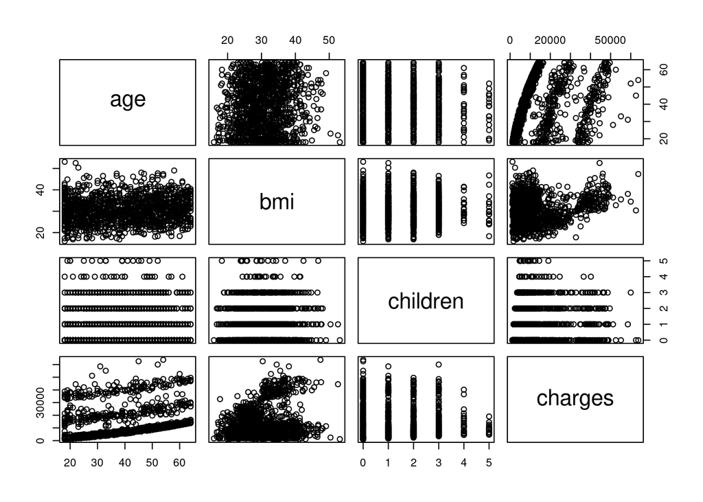

```r
pairs(numerics)
```

#### Q10: Interesting observations in scatterplots

I found the scatterplot of the BMI and charges to be particularly interesting.

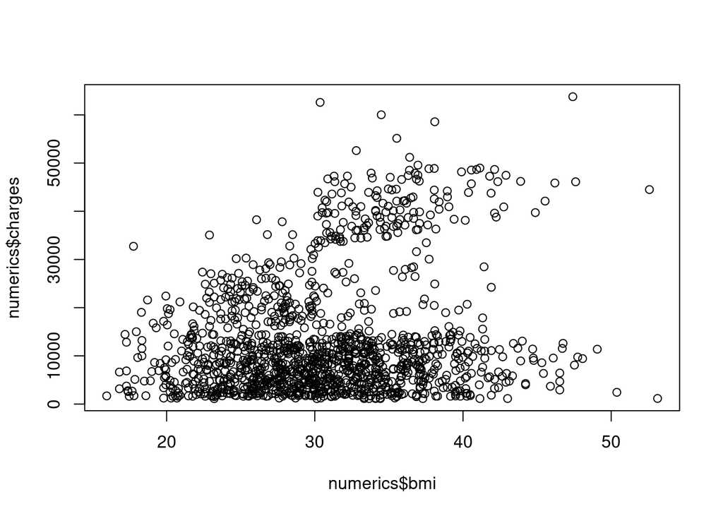

```r
plot(numerics$bmi, numerics$charges)
```

There are clustering patterns of high and low charges for the same BMI range (approx 30-40 BMI). The visual disparity of these two clusters indicate that there is a pattern of healthcare spending for these individuals, and because the data is not evenly distributed through the cost spectrum in this range of BMI values, there may be an underlying pattern or set of circumstances dictating this behavior.

#### Q11: enhanced scatterplot matrix

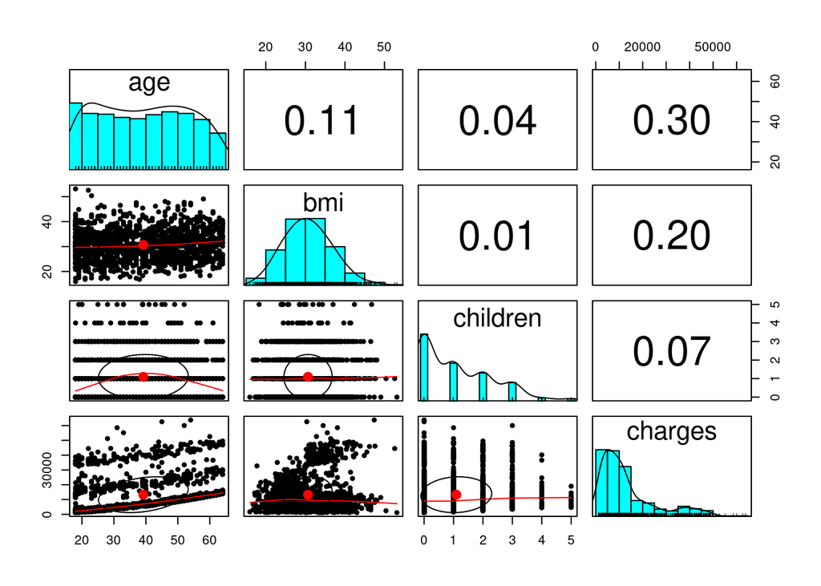

```r
library("psych")
pairs.panels(numerics)
```

## Training a model on the data

#### Q12: Generate a model in R

```r
ins_model <- lm(charges ~ age + sex + smoker + bmi + children + region, data=ins_data)
```

#### Q13: Show estimated beta coefficients

```r
ins_model
```

```
##
## Call:
## lm(formula = charges ~ age + sex + smoker + bmi + children +
##     region, data = ins_data)
##
## Coefficients:
##     (Intercept)              age          sexmale        smokeryes
##        -11938.5            256.9           -131.3          23848.5
##             bmi         children  regionnorthwest  regionsoutheast
##           339.2            475.5           -353.0          -1035.0
## regionsouthwest
##          -960.1
```

- There are 8 coefficients listed instead of 6 because each nominal category in the “Region” data column is listed as a separate feature/variable.
- The beta value for each feature is the linear rate of change of `y` for each unit of change in the indepenent variable `x_i`. For example, each point increase in `BMI` causes the dependent variable `charges` to increase approximately $339.2.

#### Q14: What increase or decrease will affect the medical expenses for each additional child? Or each additional year of age? Or unit increase of BMI?

Based on the coefficient values: * Each additional child will cause charges to increase approximately $475.00 * Each additional year of age will cause charges to increase approximately $257.00 * Each additional point increase in the example’s BMI will cause charges to increase approximately $340.00

#### Q15: Explain the effect of medical expenses in numbers on each one of the 3 factor features.

- For the `sex` (gender) feature, the average cost will decrease when the example is male (relative to a female example).
- For the `smoker` feature, the average cost will increase dramatically (about $23,000 dollars).
- For the `region` feature, the enumerated values (`regionnorthwest`, `regionsoutheast`, and `regionsouthwest`) each result in a decrease in cost relative to the baseline category (deduced to be `regionnortheast`).

## Evaluating model performance

#### Q16: Evaluate model using `summary()`

```r
summary(ins_model)
```

```
##
## Call:
## lm(formula = charges ~ age + sex + smoker + bmi + children +
##     region, data = ins_data)
##
## Residuals:
##      Min       1Q   Median       3Q      Max
## -11304.9  -2848.1   -982.1   1393.9  29992.8
##
## Coefficients:
##                 Estimate Std. Error t value Pr(>|t|)
## (Intercept)     -11938.5      987.8 -12.086  < 2e-16 ***
## age                256.9       11.9  21.587  < 2e-16 ***
## sexmale           -131.3      332.9  -0.394 0.693348
## smokeryes        23848.5      413.1  57.723  < 2e-16 ***
## bmi                339.2       28.6  11.860  < 2e-16 ***
## children           475.5      137.8   3.451 0.000577 ***
## regionnorthwest   -353.0      476.3  -0.741 0.458769
## regionsoutheast  -1035.0      478.7  -2.162 0.030782 *
## regionsouthwest   -960.0      477.9  -2.009 0.044765 *
## ---
## Signif. codes:  0 '***' 0.001 '**' 0.01 '*' 0.05 '.' 0.1 ' ' 1
##
## Residual standard error: 6062 on 1329 degrees of freedom
## Multiple R-squared:  0.7509, Adjusted R-squared:  0.7494
## F-statistic: 500.8 on 8 and 1329 DF,  p-value: < 2.2e-16
```

#### Q17: Reflect on the model’s accuracy in context of important performance indicators

[output not shown]

## Improving the Model

First, the `age` feature will be described as a non-linear (polynomial/quadratic) relationship with the dependent variable instead of a linear relationship.

```r
ins_data$age2 <- ins_data$age^2
```

Next, the BMI numeric value will be converted to a binary indicator.

```r
ins_data$bmi30 <- ifelse(ins_data$bmi >= 30, 1, 0)
```

#### Q18: Train the Improved Model

Finally, we include an interaction between high BMI and smoking in our new model.

```r
ins_model_v2 <- lm(charges ~ age2 + sex + smoker + bmi30 + bmi30*smoker + children + region, data=ins_data)
```

```r
ins_model_changes_only <- lm(charges ~ bmi30*smoker, data = ins_data)
```

```r
summary(ins_model_v2)
```

```
##
## Call:
## lm(formula = charges ~ age2 + sex + smoker + bmi30 + bmi30 *
##     smoker + children + region, data = ins_data)
##
## Residuals:
##      Min       1Q   Median       3Q      Max
## -18010.8  -1558.3  -1408.0   -919.7  24138.3
##
## Coefficients:
##                  Estimate Std. Error t value Pr(>|t|)
## (Intercept)      2522.179    372.750   6.766 1.97e-11 ***
## age2                3.355      0.109  30.780  < 2e-16 ***
## sexmale          -484.229    245.294  -1.974  0.04858 *
## smokeryes       13360.539    441.493  30.262  < 2e-16 ***
## bmi30             120.403    279.096   0.431  0.66624
## children          666.145    101.351   6.573 7.08e-11 ***
## regionnorthwest  -290.435    350.615  -0.828  0.40762
## regionsoutheast  -580.615    345.781  -1.679  0.09336 .
## regionsouthwest -1156.671    351.389  -3.292  0.00102 **
## smokeryes:bmi30 19873.858    606.747  32.755  < 2e-16 ***
## ---
## Signif. codes:  0 '***' 0.001 '**' 0.01 '*' 0.05 '.' 0.1 ' ' 1
##
## Residual standard error: 4462 on 1328 degrees of freedom
## Multiple R-squared:  0.8651, Adjusted R-squared:  0.8642
## F-statistic: 946.6 on 9 and 1328 DF,  p-value: < 2.2e-16
```

```r
summary(ins_model_changes_only)
```

```
##
## Call:
## lm(formula = charges ~ bmi30 * smoker, data = ins_data)
##
## Residuals:
##    Min     1Q Median     3Q    Max
## -19414  -4336  -1055   2987  28068
##
## Coefficients:
##                 Estimate Std. Error t value Pr(>|t|)
## (Intercept)       7977.0      263.6  30.267   <2e-16 ***
## bmi30              865.7      362.6   2.387   0.0171 *
## smokeryes        13386.2      582.9  22.965   <2e-16 ***
## bmi30:smokeryes  19329.1      801.4  24.119   <2e-16 ***
## ---
## Signif. codes:  0 '***' 0.001 '**' 0.01 '*' 0.05 '.' 0.1 ' ' 1
##
## Residual standard error: 5905 on 1334 degrees of freedom
## Multiple R-squared:  0.7628, Adjusted R-squared:  0.7622
## F-statistic:  1430 on 3 and 1334 DF,  p-value: < 2.2e-16
```